# Informe Final

Fabricio Sánchez

2 de agosto de 2015

### Introducción

En el presente informe se detallarán los pasos realizados en trabajo final de R. ### Descripción

### 2.1

Usando **readxl** leemos las datas del proyecto y procedemos a analizar sus dimensiones. Usando **datatable** de la libreía **DT** creamos un widget de las tablas para ser observadas.

```r
options(warn=-1)
library(readxl)
library(DT)
data1 <- read_excel("poblacion1.xlsx",sheet=1,col_names = TRUE,na = "")
str(data1)
```

```
## Classes 'tbl_df', 'tbl' and 'data.frame':    44 obs. of  4 variables:
##  $ identificador : num  1001 1002 1003 1004 1005 ...
##  $ poblacion     : num  18.7 13.8 13.4 11.4 10.5 10.3 10.3 10.3 10.3 9.4 ...
##  $ var.pobl.mayor: num  6.2 7.2 7.1 2.6 2.8 1.4 -0.5 3 -1.9 -1.5 ...
##  $ menores.18    : num  39.7 10.4 20.4 38.7 36.4 29.8 31.8 31.1 15.9 22.4 ...
```

```r
datatable(data1)
```

|  | identificador | poblacion | var.pobl.mayor | menores.18 |
| --- | --- | --- | --- | --- |
| 1 | 1001 | 18.7 | 6.2 | 39.7 |
| 2 | 1002 | 13.8 | 7.2 | 10.4 |
| 3 | 1003 | 13.4 | 7.1 | 20.4 |
| 4 | 1004 | 11.4 | 2.6 | 38.7 |
| 5 | 1005 | 10.5 | 2.8 | 36.4 |
| 6 | 1006 | 10.3 | 1.4 | 29.8 |
| 7 | 1007 | 10.3 | -0.5 | 31.8 |
| 8 | 1008 | 10.3 | 3 | 31.1 |
| 9 | 1009 | 10.3 | -1.9 | 15.9 |
| 10 | 1010 | 9.4 | -1.5 | 22.4 |

[output cut: 34 more lines]

```r
dim(data1)
```

```
## [1] 44  4
```

```r
data2 <- read_excel("poblacion2.xlsx",sheet=1,col_names = TRUE,na="")
str(data2)
```

```
## Classes 'tbl_df', 'tbl' and 'data.frame':    40 obs. of  7 variables:
##  $ identificador  : num  1044 1042 1010 1009 1008 ...
##  $ part.almz.escl : num  73.8 34.4 22.2 39.9 51.7 57.2 43.7 72.3 78.2 13.9 ...
##  $ var.ingresos   : num  50.5 24.2 33.5 38.5 26.2 27.2 29.4 26 18.4 22.5 ...
##  $ tasa.crimen    : num  704.1 179.9 61.5 86.4 42.4 ...
##  $ var.tasa.crimen: num  -40.9 12.3 -32.7 -13.5 -31.9 -17.6 -10 -21.6 -12.8 -33.6 ...
##  $ region         : chr  "B" "B" "A" "A" ...
##  $ serv.bas.compl : chr  "SI" "NO" "NO" "SI" ...
```

```r
datatable(data2)
```

|  | identificador | part.almz.escl | var.ingresos | tasa.crimen | var.tasa.crimen | region | serv.bas.compl |
| --- | --- | --- | --- | --- | --- | --- | --- |
| 1 | 1044 | 73.8 | 50.5 | 704.1 | -40.9 | B | SI |
| 2 | 1042 | 34.4 | 24.2 | 179.9 | 12.3 | B | NO |
| 3 | 1010 | 22.2 | 33.5 | 61.5 | -32.7 | A | NO |
| 4 | 1009 | 39.9 | 38.5 | 86.4 | -13.5 | A | SI |
| 5 | 1008 | 51.7 | 26.2 | 42.4 | -31.9 | A | NO |
| 6 | 1007 | 57.2 | 27.2 | 61.2 | -17.6 | A | NO |
| 7 | 1006 | 43.7 | 29.4 | 54 | -10 | A | NO |
| 8 | 1005 | 72.3 | 26 | 77.5 | -21.6 | A | SI |
| 9 | 1004 | 78.2 | 18.4 | 86.6 | -12.8 | A | NO |
| 10 | 1003 | 13.9 | 22.5 | 38.3 | -33.6 | A | NO |

[output cut: 30 more lines]

```r
dim(data2)
```

```
## [1] 40  7
```

### 2.2

Usando la función **merge** unimos las dos datas en una sola llamada **poblacion** Luego la visualizamos y calculamos su dimensión

```r
options(warn=-1)
poblacion <- merge(data1,data2)
datatable(poblacion)
```

|  | identificador | poblacion | var.pobl.mayor | menores.18 | part.almz.escl | var.ingresos | tasa.crimen | var.tasa.crimen | region | serv.bas.compl |
| --- | --- | --- | --- | --- | --- | --- | --- | --- | --- | --- |
| 1 | 1001 | 18.7 | 6.2 | 39.7 | 55.8 | 28.7 | 52.6 | -2.9 | A | SI |
| 2 | 1002 | 13.8 | 7.2 | 10.4 | 57.9 | 26.2 | 111 | -22.6 | A | SI |
| 3 | 1003 | 13.4 | 7.1 | 20.4 | 13.9 | 22.5 | 38.3 | -33.6 | A | NO |
| 4 | 1004 | 11.4 | 2.6 | 38.7 | 78.2 | 18.4 | 86.6 | -12.8 | A | NO |
| 5 | 1005 | 10.5 | 2.8 | 36.4 | 72.3 | 26 | 77.5 | -21.6 | A | SI |
| 6 | 1006 | 10.3 | 1.4 | 29.8 | 43.7 | 29.4 | 54 | -10 | A | NO |
| 7 | 1007 | 10.3 | -0.5 | 31.8 | 57.2 | 27.2 | 61.2 | -17.6 | A | NO |
| 8 | 1008 | 10.3 | 3 | 31.1 | 51.7 | 26.2 | 42.4 | -31.9 | A | NO |
| 9 | 1009 | 10.3 | -1.9 | 15.9 | 39.9 | 38.5 | 86.4 | -13.5 | A | SI |
| 10 | 1010 | 9.4 | -1.5 | 22.4 | 22.2 | 33.5 | 61.5 | -32.7 | A | NO |

[output cut: 30 more lines]

```r
dim(poblacion)
```

```
## [1] 40 10
```

### 2.3

Identificamos la clase de cada variable y realizamos diagramas de cajas para variables contínuas y diagramas de barras para variables discretas

```r
options(warn=-1)
#Identificar la clase de cada variable
clase <- numeric(ncol(poblacion))
for (i in 1:ncol(poblacion)){
  clase[i] <- class(poblacion[,i])
}
clase
```

```
##  [1] "numeric"   "numeric"   "numeric"   "numeric"   "numeric"
##  [6] "numeric"   "numeric"   "numeric"   "character" "character"
```

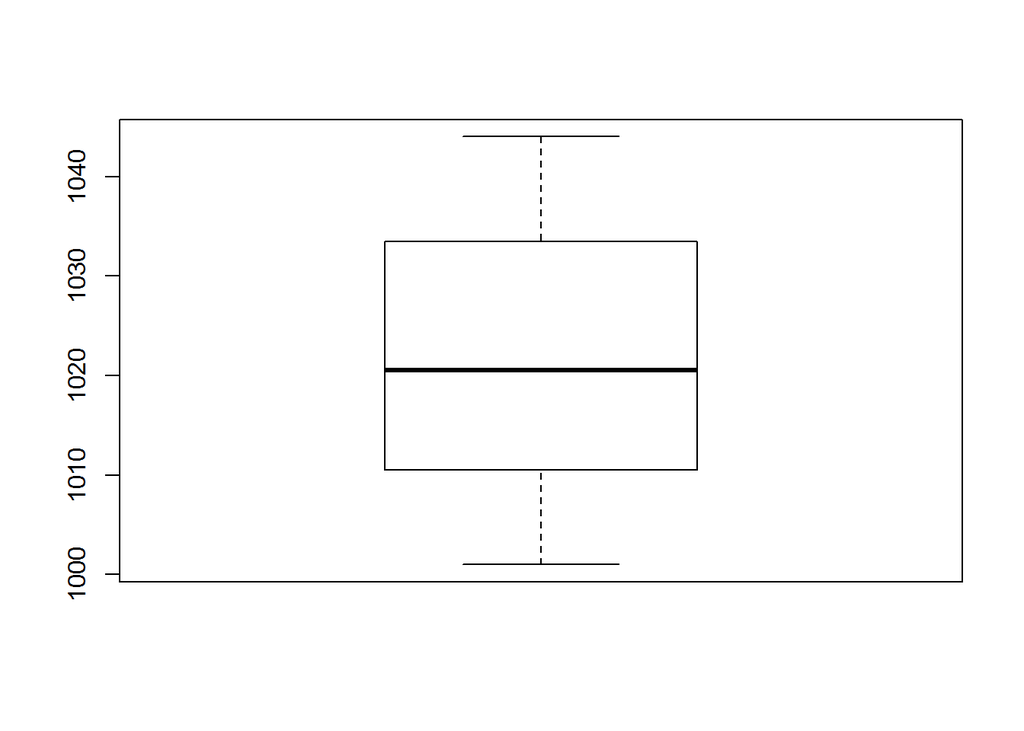

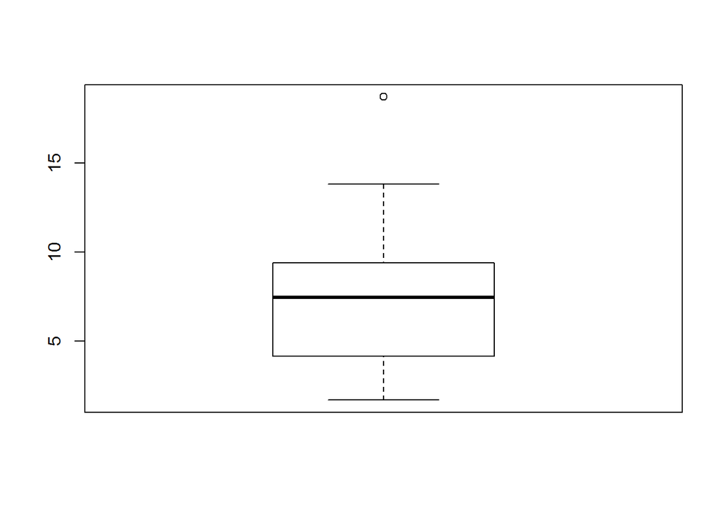

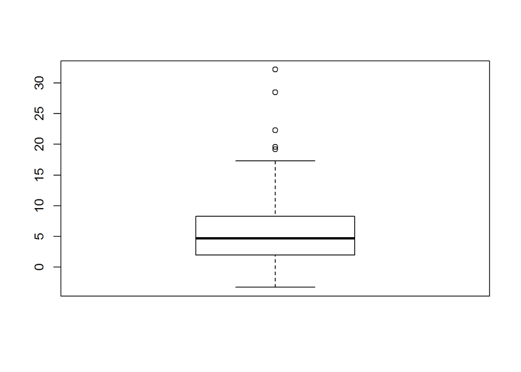

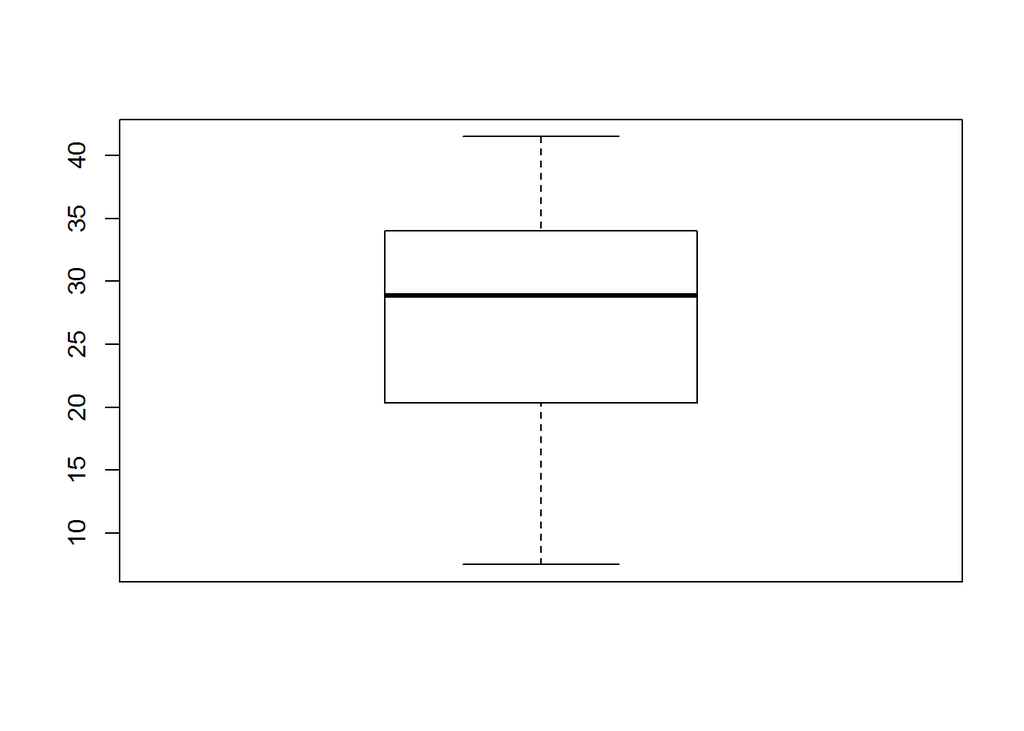

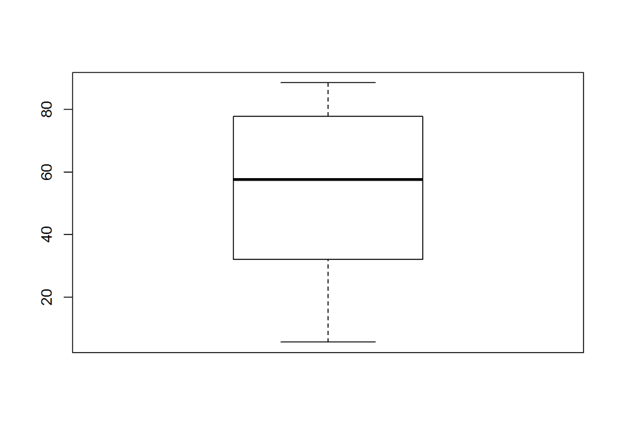

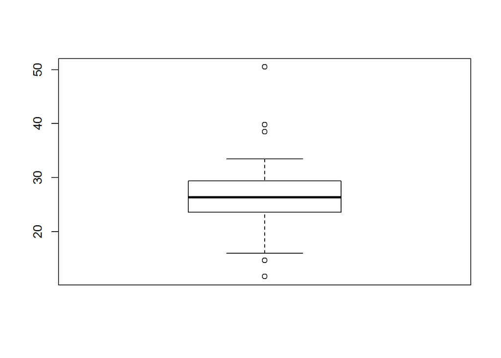

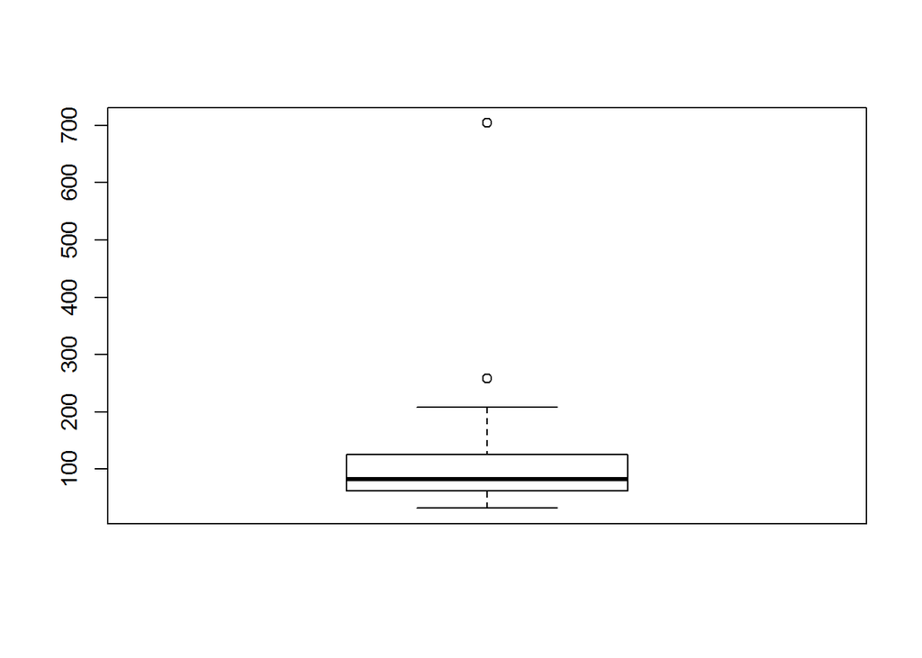

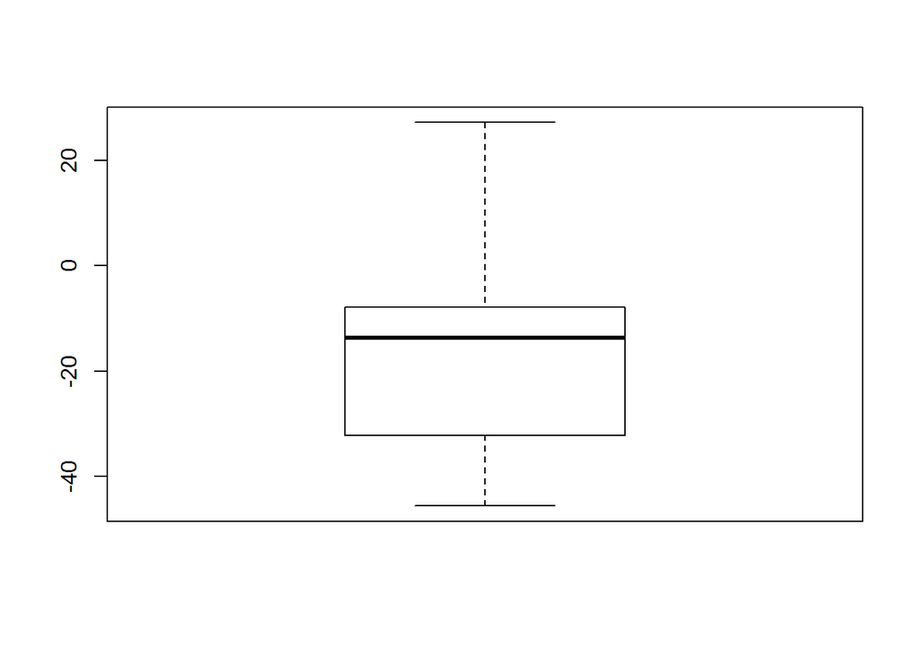

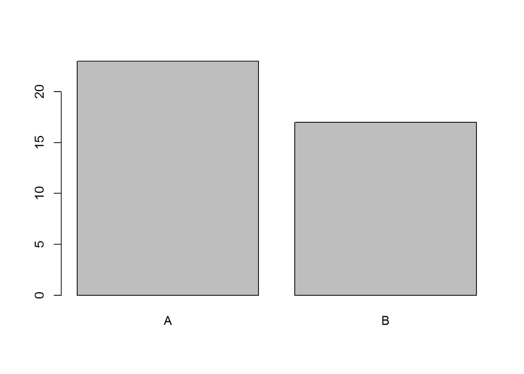

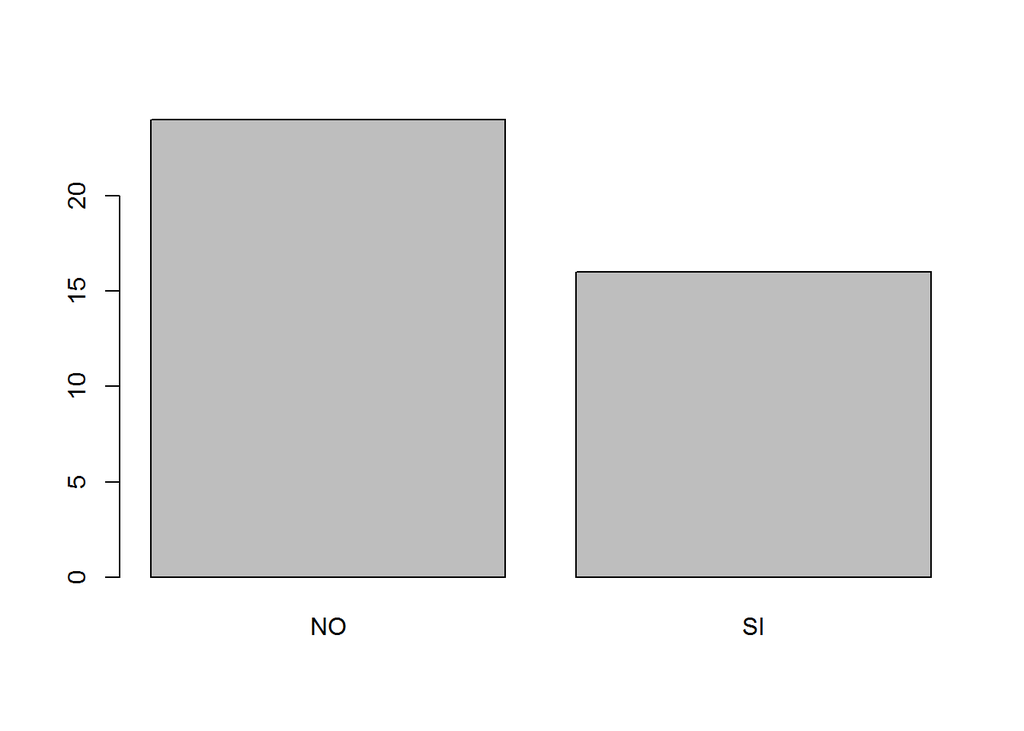

```r
#Diagramas de cajas y barras
c <- function(i){
  boxplot(poblacion[,i])
}
for (i in 1:ncol(poblacion)){
  if (is.numeric(poblacion[,i])==T){
    c(i)
  }else{
    barplot(table(poblacion[,i]))
  }
}
```

### 2.4

Calculamos el mínimo, media, máximo, desviación estándar, primer cuartil de cada variable numérica y la frecuencia en el caso de variables categóricas.

```r
options(warn=-1)
mi <- numeric(8)
ma <- numeric(8)
med <- numeric(8)
dve <- numeric(8)
for (i in 1:ncol(poblacion)){
  if (is.numeric(poblacion[,i])==T){
    mi[i] <- min(poblacion[,i])
    ma[i] <- max(poblacion[,i])
    med[i] <- mean(poblacion[,i])
    dve[i] <- sd(poblacion[,i])
  }
}
mi
```

```
## [1] 1001.0    1.7   -3.3    7.5    5.7   11.7   32.0  -45.6
```

```r
ma
```

```
## [1] 1044.0   18.7   32.2   41.5   88.5   50.5  704.1   27.2
```

```r
med
```

```
## [1] 1021.7000    7.2325    6.6475   27.0725   53.1750   26.7875  111.0350
## [8]  -15.9625
```

```r
dve
```

```
## [1]  12.993489   3.621403   8.148776   9.036337  25.420784   6.854165
## [7] 108.889133  15.758623
```

```r
#cuartiles
quantile(poblacion[,1], probs = seq(0, 1, 0.25), na.rm = FALSE)
```

```
##      0%     25%     50%     75%    100%
## 1001.00 1010.75 1020.50 1033.25 1044.00
```

```r
quantile(poblacion[,2], probs = seq(0, 1, 0.25), na.rm = FALSE)
```

```
##     0%    25%    50%    75%   100%
##  1.700  4.175  7.450  9.400 18.700
```

```r
quantile(poblacion[,3], probs = seq(0, 1, 0.25), na.rm = FALSE)
```

```
##     0%    25%    50%    75%   100%
## -3.300  1.975  4.700  8.200 32.200
```

```r
quantile(poblacion[,4], probs = seq(0, 1, 0.25), na.rm = FALSE)
```

```
##     0%    25%    50%    75%   100%
##  7.500 20.375 28.850 33.550 41.500
```

```r
quantile(poblacion[,5], probs = seq(0, 1, 0.25), na.rm = FALSE)
```

```
##     0%    25%    50%    75%   100%
##  5.700 33.250 57.550 77.525 88.500
```

```r
quantile(poblacion[,6], probs = seq(0, 1, 0.25), na.rm = FALSE)
```

```
##    0%   25%   50%   75%  100%
## 11.70 23.65 26.35 29.40 50.50
```

```r
quantile(poblacion[,7], probs = seq(0, 1, 0.25), na.rm = FALSE)
```

```
##      0%     25%     50%     75%    100%
##  32.000  62.325  81.950 124.150 704.100
```

```r
quantile(poblacion[,8], probs = seq(0, 1, 0.25), na.rm = FALSE)
```

```
##      0%     25%     50%     75%    100%
## -45.600 -32.050 -13.700  -7.975  27.200
```

```r
#frecuencias
table(poblacion[,9])
```

```
##
##  A  B
## 23 17
```

```r
table(poblacion[,10])
```

```
##
## NO SI
## 24 16
```

### 2.5

Hallamos la correlación entrela variable dependiente poblacion y cada una de las variables explicativas (numéricas).

```r
options(warn=-1)
correl <-function(i){
  correl <- numeric(ncol(poblacion))

  for(i in 2:ncol(poblacion)){
    if(is.numeric(poblacion[,i])==TRUE){
      correl[i] <- cor(poblacion[,2], poblacion[,i])
    }

  }
  datos<-data.frame(names(poblacion),correl)
  datos
}
correl(poblacion)
```

```
##    names.poblacion.      correl
## 1     identificador  0.00000000
## 2         poblacion  1.00000000
## 3    var.pobl.mayor -0.15774031
## 4        menores.18  0.19709059
## 5    part.almz.escl -0.04686172
## 6      var.ingresos -0.07677708
## 7       tasa.crimen -0.37492254
## 8   var.tasa.crimen -0.07645301
## 9            region  0.00000000
## 10   serv.bas.compl  0.00000000
```

### 2.6

Considerando la variable serv.bas.compl con una confiabilidad del 90%, ¿Pue- de asumirse que la media de la variable poblacion en el grupo serv.bas.compl: SI es distinta a la media del grupo serv.bas.compl: NO ? Para responder esta pregunta calculamos y analizamos las varianzas para proceder a una prueba de hipótesis

```r
options(warn=-1)
#para aplicar t.test necesitamos las varianzas
v1<-poblacion[,2]
v2<-poblacion[,10]
#analizamos las varianzas
var(v1[v2=="SI"])
```

```
## [1] 18.99267
```

```r
var(v1[v2=="NO"])
```

```
## [1] 9.295199
```

```r
#se evidencia que son distintas, realizamos nuestra prueba de hipotesis
t.test(v1[v2=="SI"], v1[v2=="NO"],conf.level = 0.90)
```

```
##
##  Welch Two Sample t-test
##
## data:  v1[v2 == "SI"] and v1[v2 == "NO"]
## t = 0.91985, df = 24.672, p-value = 0.3666
## alternative hypothesis: true difference in means is not equal to 0
## 90 percent confidence interval:
##  -0.9901808  3.2985141
## sample estimates:
## mean of x mean of y
##  7.925000  6.770833
```

Como $t=0.9198543$ es menor que $df=24.6721092$ se acepta $H_0: u1-u2=0$.

### 2.7

Considerando los cálculos anteriores generamos el modelo que mejor se ajuste a nuestros datos

```r
options(warn=-1)
v2<-poblacion[,2]
v7<-poblacion[,7]
reg1<-lm(v1~v2+v7)
summary(reg1)
```

```
##
## Call:
## lm(formula = v1 ~ v2 + v7)
##
## Residuals:
##        Min         1Q     Median         3Q        Max
## -7.537e-16 -1.739e-16 -7.827e-17  2.843e-17  2.535e-15
##
## Coefficients:
##               Estimate Std. Error    t value Pr(>|t|)
## (Intercept) -1.606e-15  2.193e-16 -7.323e+00 1.06e-08 ***
## v2           1.000e+00  2.227e-17  4.489e+16  < 2e-16 ***
## v7           6.377e-19  7.408e-19  8.610e-01    0.395
## ---
## Signif. codes:  0 '***' 0.001 '**' 0.01 '*' 0.05 '.' 0.1 ' ' 1
##
## Residual standard error: 4.67e-16 on 37 degrees of freedom
## Multiple R-squared:      1,  Adjusted R-squared:      1
## F-statistic: 1.173e+33 on 2 and 37 DF,  p-value: < 2.2e-16
```

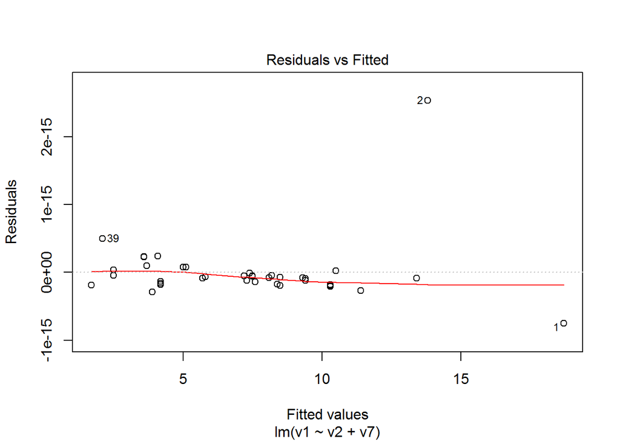

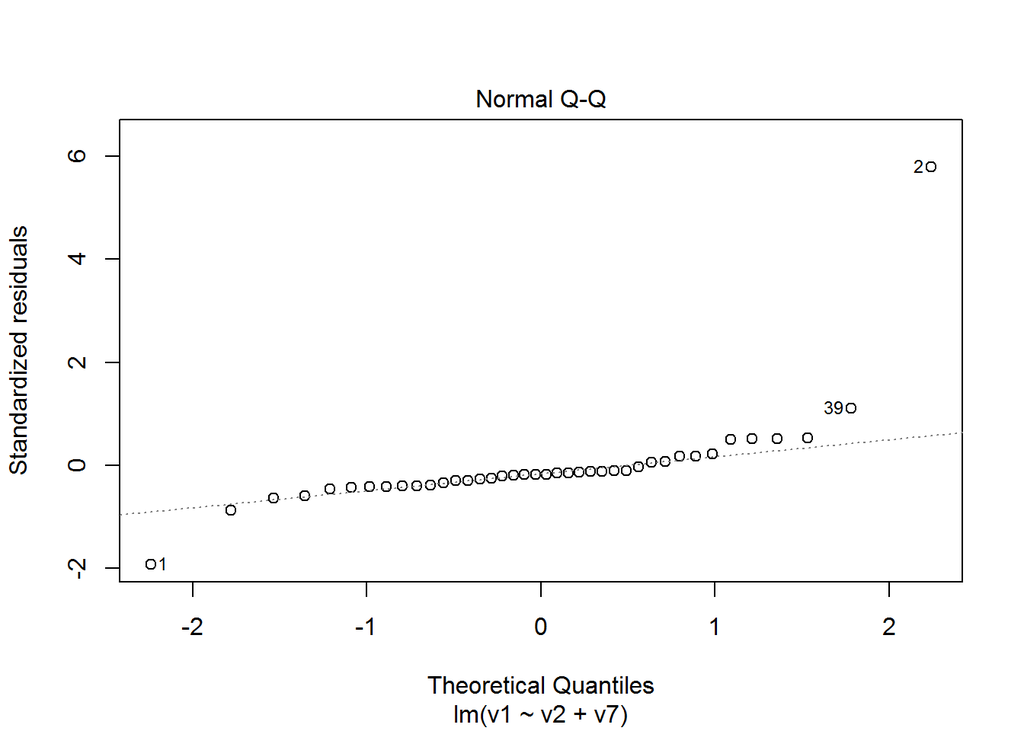

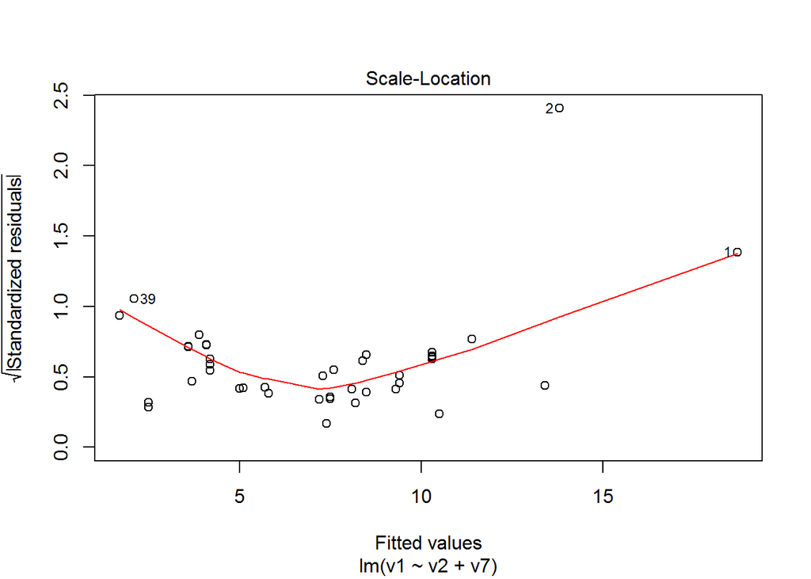

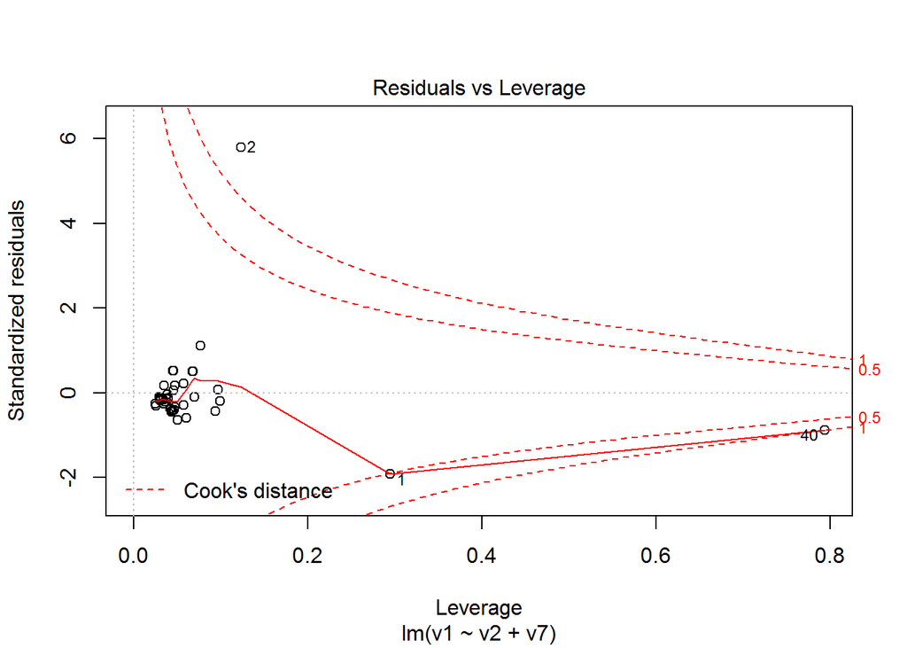

```r
plot(reg1)
```

### 2.8

Procedemos a analizar el **R^2**

Como $R^2 = 1$ podemos decir que aproximadamente el $100$% de nuestra variación puede ser explicado por este modelo, además el $R^2 ajustado = 1$ por lo tanto la regresión es significativa.

### 2.9

Debemos analizar la significancia de la regresión y de cada uno de los parámetros. Para esto usaremos gráficos de dispersión, gráficos de normalidad e histogramas para v1, v2 y v7.

**Gráficos de Dispersión** **1**

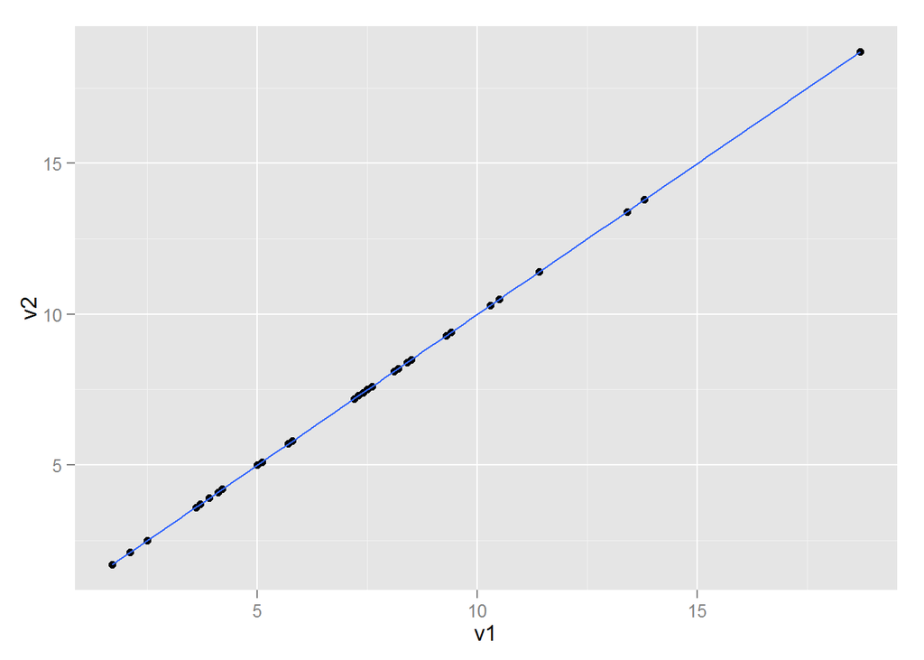

```r
options(warn=-1)
library("ggplot2")
g <- ggplot(poblacion, aes(x=v1, y=v2))
g + geom_point() + geom_smooth(method="lm")
```

Se puede observar que hay relación lineal **2**

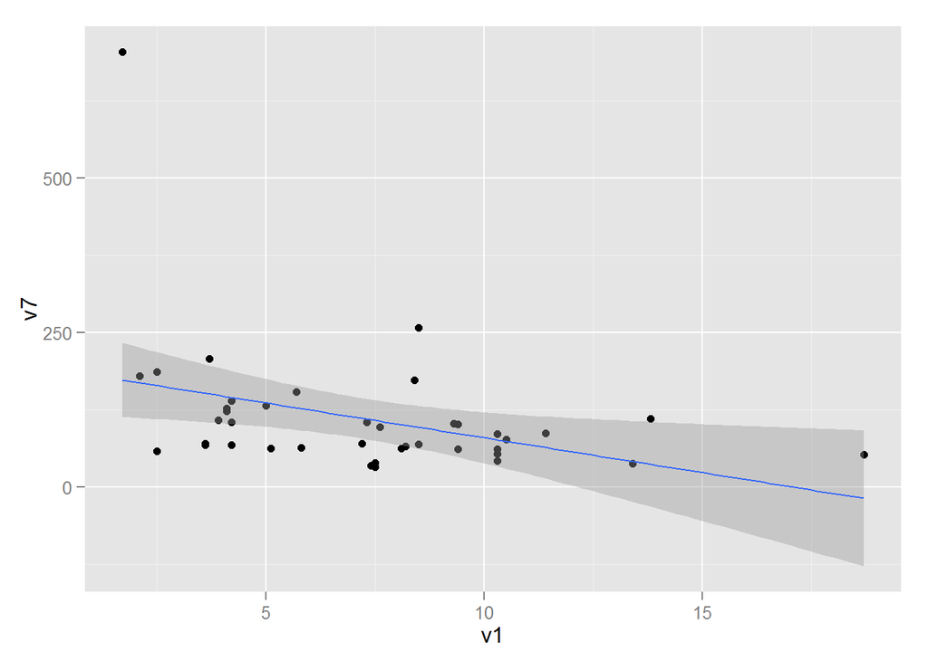

```r
options(warn=-1)
g <- ggplot(poblacion, aes(x=v1, y=v7))
g + geom_point() + geom_smooth(method="lm")
```

Existe mayor dispersión **3**

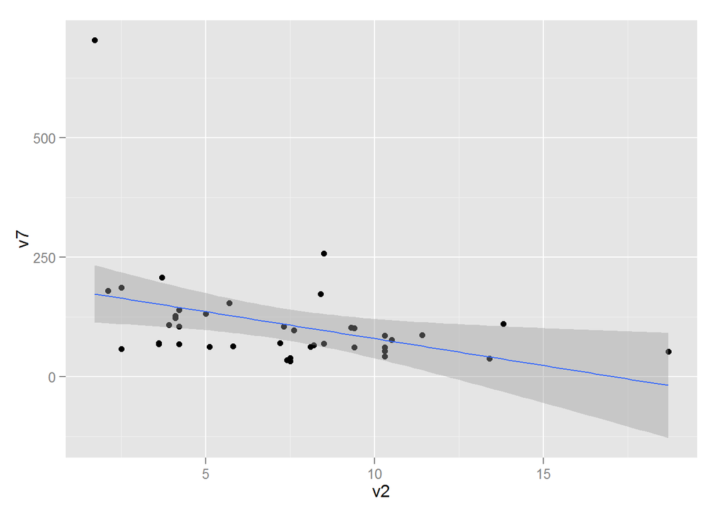

```r
options(warn=-1)
g <- ggplot(poblacion, aes(x=v2, y=v7))
g + geom_point() + geom_smooth(method="lm")
```

Existe mayor dispersión

**Gráficos de Normalidad**

**1**

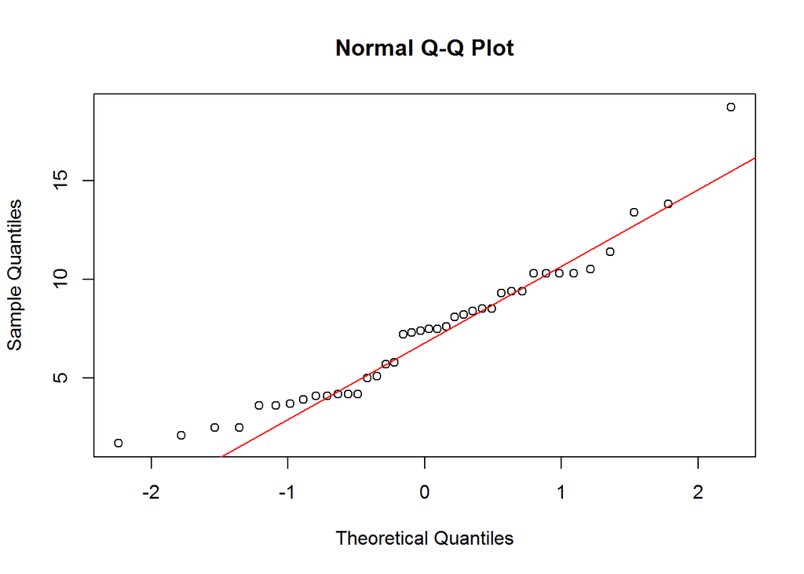

```r
options(warn=-1)
qqnorm(v1)
qqline(v1,col="red")
```

Es notable que no se cumple el supuesto de normalidad **2**

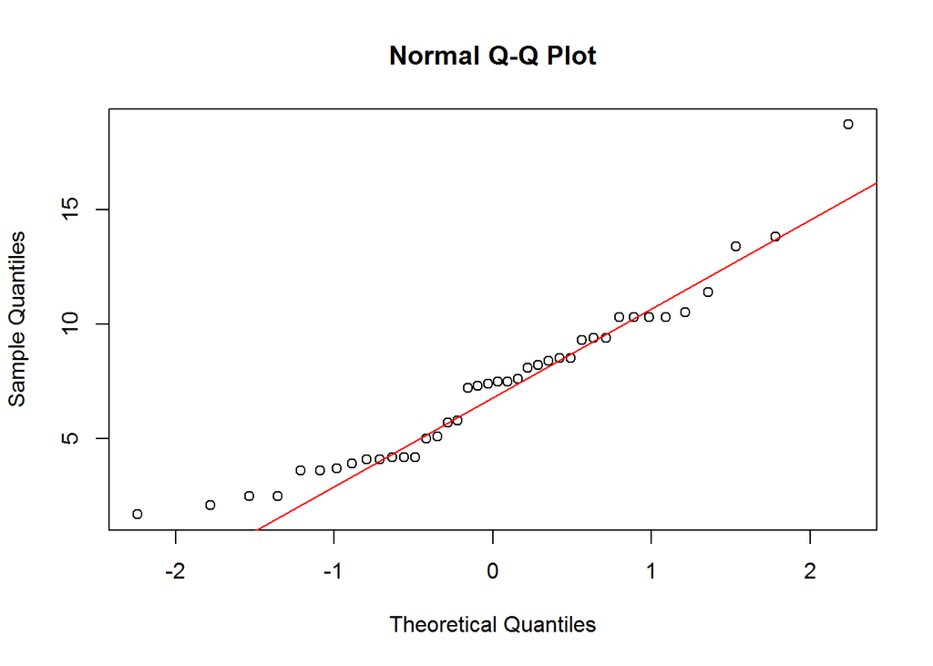

```r
options(warn=-1)
qqnorm(v2)
qqline(v2,col="red")
```

Es notable que no se cumple el supuesto de normalidad **3**

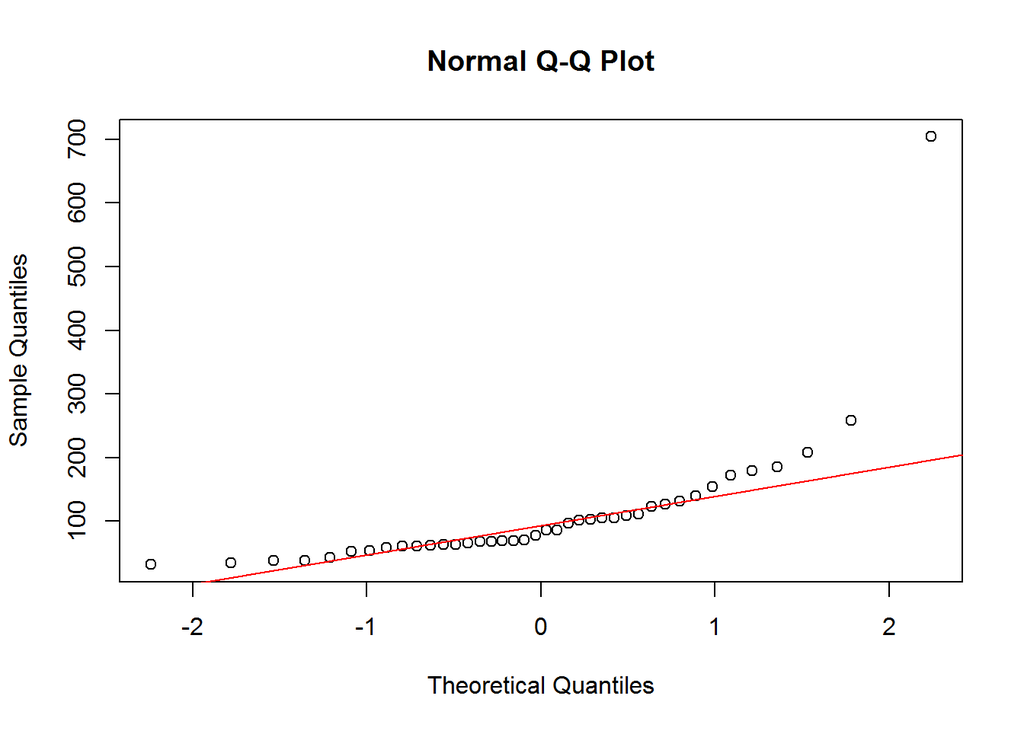

```r
options(warn=-1)
qqnorm(v7)
qqline(v7,col="red")
```

**Histogramas**

**1**

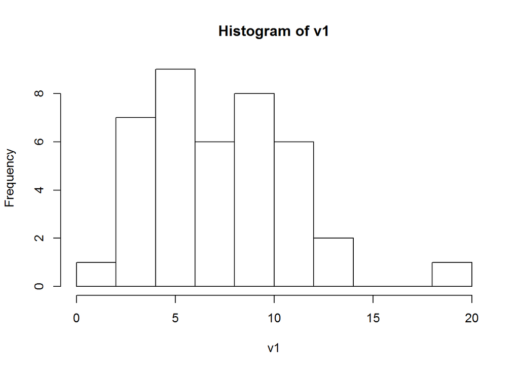

```r
options(warn=-1)
hist(v1)
```

**2**

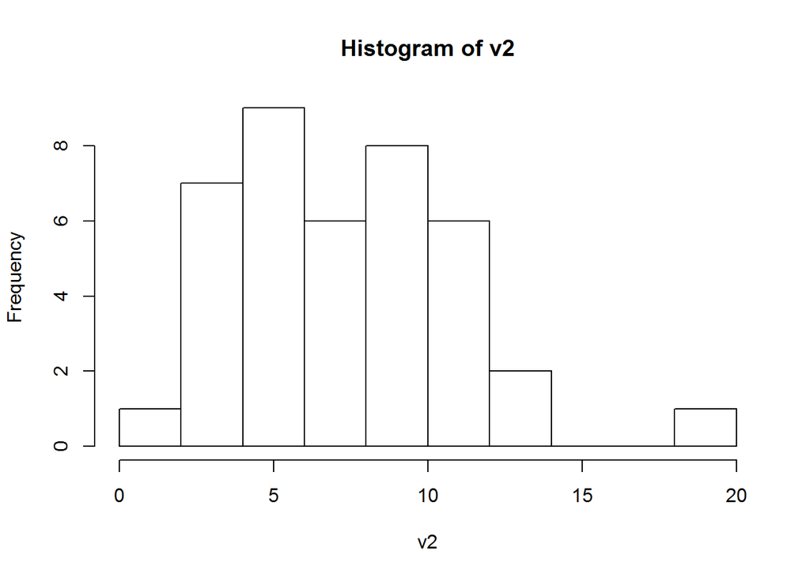

```r
options(warn=-1)
hist(v2)
```

Tendencia a normalidad y simetría **3**

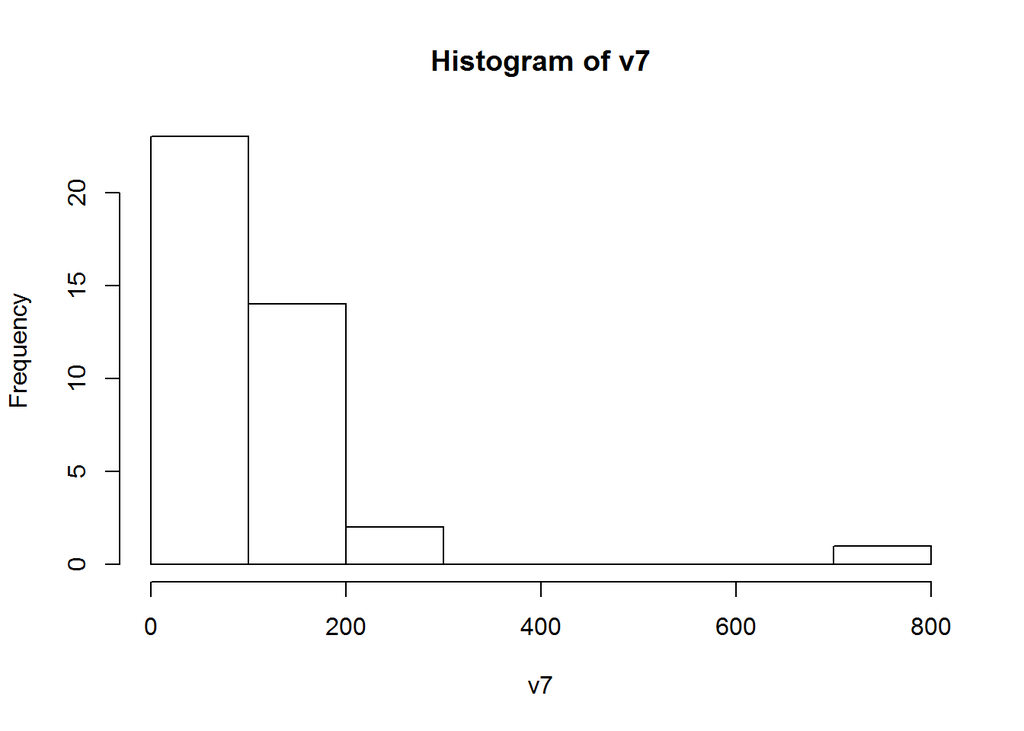

```r
options(warn=-1)
hist(v7)
```

### 2.10

Ahora procedemos a realizar un análisis detallado de los residuos

**Residuos**

```r
options(warn=-1)
res1<- reg1$residuals
```

Comparemos los residuos con v1, v2 y v7

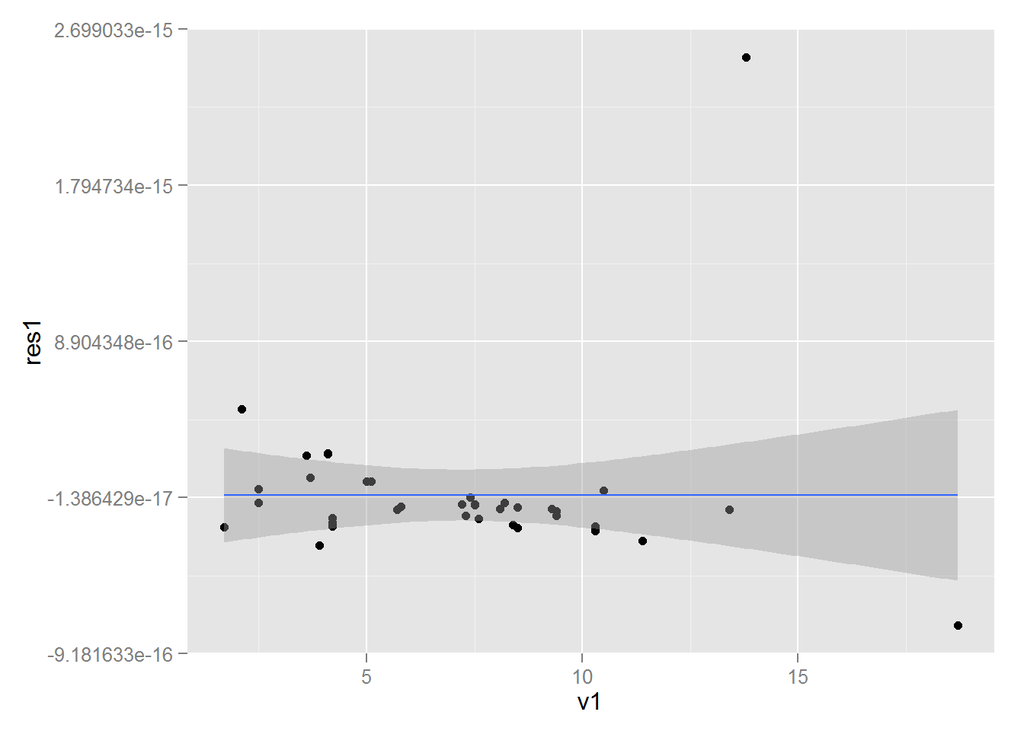

```r
options(warn=-1)
g <- ggplot(poblacion, aes(x=v1, y=res1))
g + geom_point() + geom_smooth(method="lm")
```

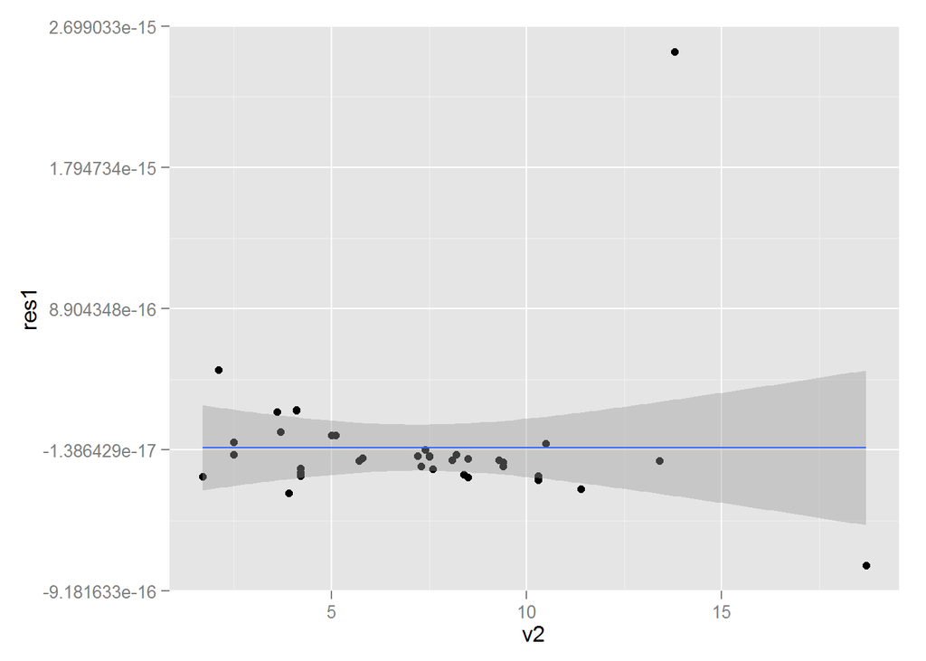

```r
g <- ggplot(poblacion, aes(x=v2, y=res1))
g + geom_point() + geom_smooth(method="lm")
```

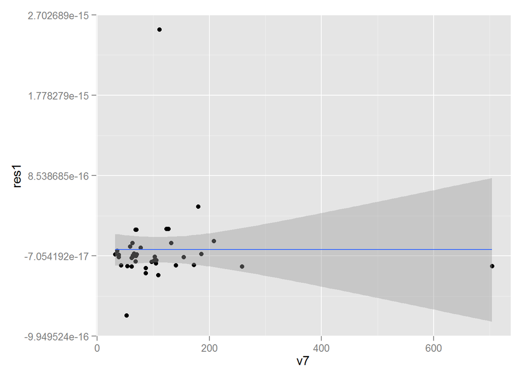

```r
g <- ggplot(poblacion, aes(x=v7, y=res1))
g + geom_point() + geom_smooth(method="lm")
```

Es observable que no tienen una distribución aleatoria en una banda con centro en cero Procedemos a comparar los residuos con los pronósticos de nuestro modelo

**Pronóstios vs Residuos**

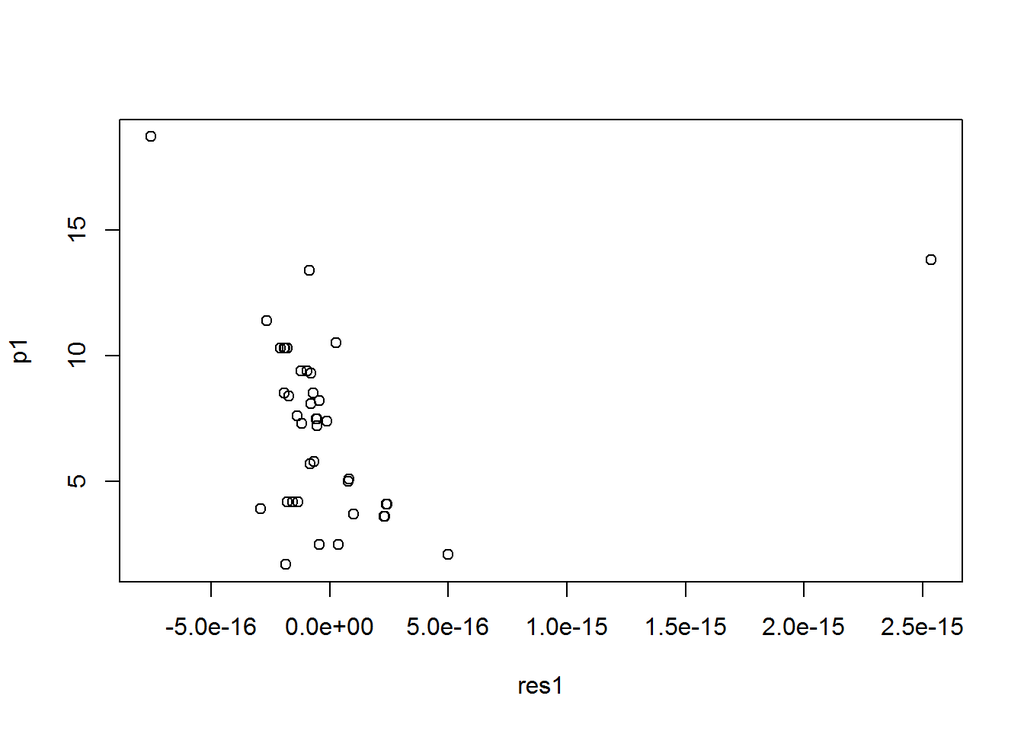

```r
options(warn=-1)
p1 <- reg1$fitted.values
plot(res1,p1)
```

Se observa que la linealidad se ve afectada debido a la disperción de los puntos y a la existencia de puntos atípicos e influyentes. Por lo notado anteriormente se concluye que requerimos de un ajuste de nuestro modelo original.

**Reajuste**

```r
vaj1<-log(v1)
vaj2<-log(v2)
vaj7<-log(v7)
reg2<-lm(vaj1~vaj2+vaj7)
summary(reg2)
```

```
##
## Call:
## lm(formula = vaj1 ~ vaj2 + vaj7)
##
## Residuals:
##        Min         1Q     Median         3Q        Max
## -5.441e-17 -2.866e-17 -6.105e-18  3.711e-18  2.569e-16
##
## Coefficients:
##               Estimate Std. Error    t value Pr(>|t|)
## (Intercept) -4.096e-16  9.306e-17 -4.402e+00 8.79e-05 ***
## vaj2         1.000e+00  1.764e-17  5.669e+16  < 2e-16 ***
## vaj7         2.998e-17  1.596e-17  1.878e+00   0.0682 .
## ---
## Signif. codes:  0 '***' 0.001 '**' 0.01 '*' 0.05 '.' 0.1 ' ' 1
##
## Residual standard error: 5.174e-17 on 37 degrees of freedom
## Multiple R-squared:      1,  Adjusted R-squared:      1
## F-statistic: 2.19e+33 on 2 and 37 DF,  p-value: < 2.2e-16
```

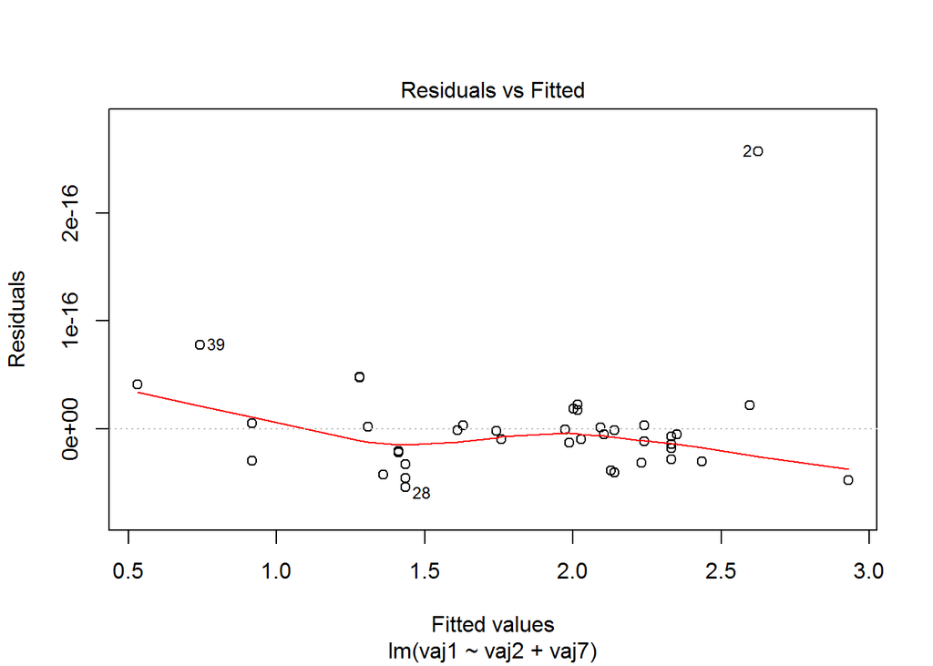

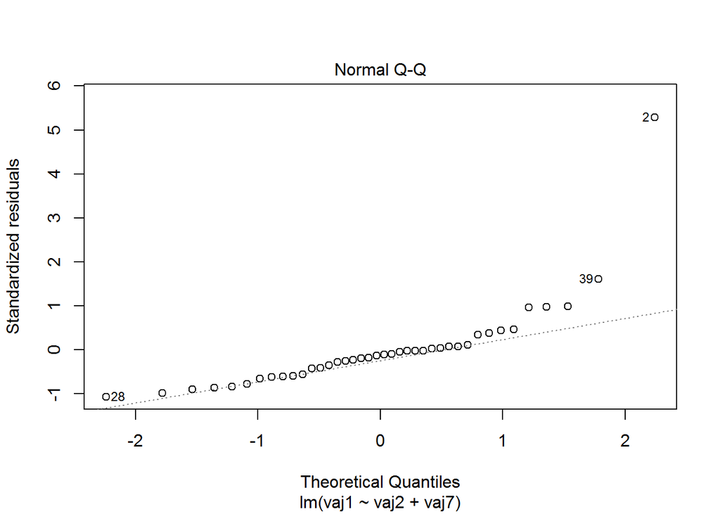

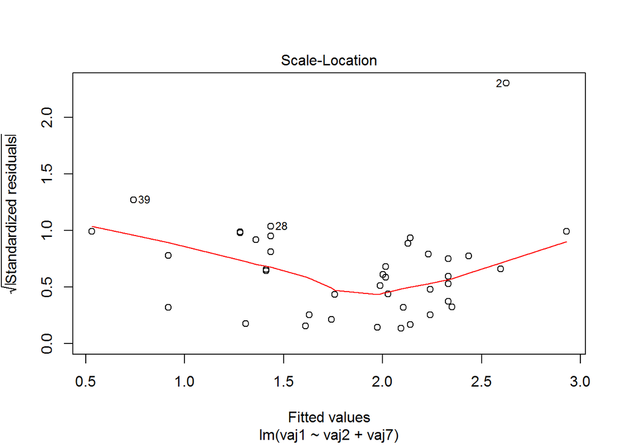

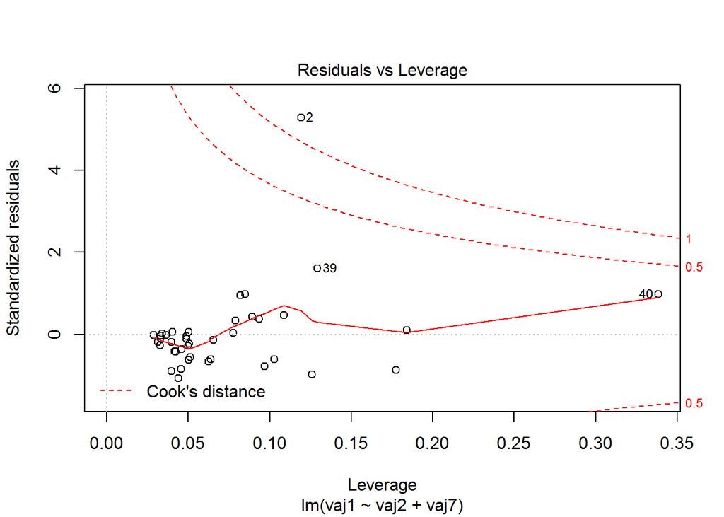

```r
plot(reg2)
```

Ahora vemos que el modelo se ajusta mejor a la linealidad que el modelo original ademas se puede aceptar el modelo de regresion multiple.